# Social stat

## Cơ sở lý thuyết

**Giới thiệu về dữ liệu**

Dữ liệu từ Điều tra xã hội chung 2016 (GSS16) Sự miêu tả GSS thu thập dữ liệu về xã hội Mỹ đương đại để theo dõi và giải thích các xu hướng và hằng số về thái độ, hành vi và thuộc tính. Hàng trăm xu hướng đã được theo dõi kể từ năm 1972. Ngoài ra, kể từ khi GSS áp dụng các câu hỏi từ các cuộc khảo sát trước đó, các xu hướng có thể được theo dõi trong tối đa 70 năm. GSS chứa cốt lõi tiêu chuẩn gồm các câu hỏi về nhân khẩu học, hành vi và thái độ, cộng với các chủ đề được quan tâm đặc biệt. Trong số các chủ đề được đề cập là quyền tự do dân sự, tội phạm và bạo lực, lòng khoan dung giữa các nhóm, đạo đức, ưu tiên chi tiêu quốc gia, sức khỏe tâm lý, tính di động xã hội, căng thẳng và các sự kiện đau buồn.

Chi tiết Dữ liệu đến từ NORC tại Đại học Chicago. Dữ liệu đã được sửa đổi để phục vụ tốt hơn cho các mục tiêu giáo dục cơ bản về khoa học dữ liệu. Chỉ có 9 trong số 935 biến ban đầu được chọn cho tập dữ liệu này.

Đối tượng nghiên cứu

Trong nhiệm vụ này, chúng tôi phân tích dữ liệu từ GSS 2016, sử dụng nó để ước tính giá trị dân số các thông số quan tâm về người lớn ở Hoa Kỳ. Định dạng GSS16 chứa 2867 hàng và 9 cột.

Các trường được sử dụng để nghiên cứu

- harass5: Trả lời câu hỏi "Trong 5 năm qua, bạn có bị cấp trên hoặc đồng nghiệp quấy rối tại nơi làm việc không, ví dụ, bạn có bị bắt nạt, lạm dụng thể chất hoặc tâm lý không?" Các câu trả lời có thể là Có, Không và Không áp dụng.
- emalmin: Số thư điện tử Số phút dành cho email hàng tuần; thêm vào số giờ trong emailhrs (ví dụ: emailmin = 30 trong 2,5 giờ trên email).
- emailhr: thư điện tử Số giờ dành cho email hàng tuần.
- educ: Số năm đi học.
- polviews: Quan điểm chính trị. Trả lời câu hỏi "Ngày nay chúng ta nghe nói nhiều về phe tự do và phe bảo thủ. Tôi sẽ cho bạn thấy một thang điểm bảy mà trên đó các quan điểm chính trị mà mọi người có thể nắm giữ được sắp xếp từ cực kỳ tự do--điểm 1--đến cực kỳ bảo thủ-- điểm 7. Bạn sẽ đặt mình ở đâu trên thang điểm này?" Các câu trả lời có thể là Cực kỳ tự do, Tự do, Hơi tự do, Trung bình, Hơi bảo thủ, Bảo thủ, Cực kỳ bảo thủ.
- Advfront: Trả lời cho câu hỏi "Ngay cả khi nó không mang lại lợi ích ngay lập tức, nghiên cứu khoa học nhằm nâng cao tri thức là cần thiết và cần được chính phủ liên bang hỗ trợ." Các câu trả lời có thể là Rất đồng ý, Đồng ý, Không biết, Không đồng ý và Rất không đồng ý.
- snapchat: người trả lời sẽ trả lời câu hỏi có sử dụng Snapchat hay không.
- instagram: người trả lời sẽ trả lời câu hỏi có sử dụng Instagram hay không.
- Wrkstat: Tình trạng công việc.

**Phát biểu bài toán:**

Bài toán được đặt ra để trả lời câu hỏi về mức độ sử dụng email dựa trên công việc; tần suất sử dụng một số mạng xã hội như Snapchat, Instagram; số năm đi học; quan điểm về chính trị, nghiên cứu khoa học; và việc có bị quấy rối, bắt nạt hay không.

**Giới thiệu lý thuyết:**

**Mô hình GLM (Generalized Linear Model)** là một họ các mô hình thống kê mạnh mẽ và linh hoạt được sử dụng để mô hình hóa mối quan hệ giữa biến phụ thuộc và các biến độc lập trong các tình huống không phải là phân phối chuẩn. GLM mở rộng mô hình hồi quy tuyến tính thông thường để bao gồm các phân phối khác và các hàm liên kết không tuyến tính để xác định mối quan hệ giữa biến phụ thuộc và biến độc lập.

Mô hình GLM bao gồm ba thành phần chính:

- Hàm Liên kết (Link function): Đây là hàm xác định mối quan hệ giữa giá trị kỳ vọng của biến phụ thuộc và tổng trọng số của biến độc lập. Hàm liên kết cần phải là một hàm liên tục, đồng biến và có đạo hàm.
- Phân phối (Distribution): Đây là phân phối xác định biểu diễn phân phối của biến phụ thuộc. Các phân phối thường được sử dụng trong GLM bao gồm phân phối Poisson (cho mô hình đếm), phân phối Gaussian (cho mô hình hồi quy tuyến tính), phân phối Bernoulli (cho mô hình logistic), và nhiều phân phối khác.
- Hàm liên hệ (Link function): Đây là một ánh xạ giữa giá trị kỳ vọng của biến phụ thuộc và tổng trọng số của biến độc lập. Ví dụ, trong mô hình hồi quy tuyến tính, hàm liên hệ thường là hàm đồng biến (identity function) để duy trì mối quan hệ tuyến tính. Trong trường hợp của mô hình logistic, hàm liên hệ là hàm logit.

Mô hình GLM có thể được sử dụng cho nhiều loại dữ liệu và mục tiêu khác nhau, bao gồm:

- Hồi quy tuyến tính (Linear Regression): Sử dụng khi biến phụ thuộc là liên tục và phân phối Gaussian.
- Hồi quy logistic (Logistic Regression): Sử dụng khi biến phụ thuộc là nhị phân (0/1) và phân phối Bernoulli. Thường được sử dụng trong dự đoán xác suất của một sự kiện.
- Hồi quy Poisson (Poisson Regression): Sử dụng khi biến phụ thuộc là số lượng đếm và phân phối Poisson. Thường được sử dụng trong việc mô hình hóa tần suất của các sự kiện.
- Hồi quy nhị thức âm (Negative Binomial Regression): Sử dụng khi biến phụ thuộc là số lượng đếm và phân phối negative binomial. Thường được sử dụng khi dữ liệu có phương sai không ổn định hơn so với phân phối Poisson.

**Lý thuyết Bayes Generalized Linear Model (Bayes GLM)** là một phương pháp thống kê kết hợp lý thuyết Bayes và mô hình tuyến tính tổng quát (Generalized Linear Model - GLM) để ước tính tham số và dự đoán trong mô hình tuyến tính mà đầu vào không phải là dữ liệu có phân phối chuẩn.

Để hiểu rõ hơn về Bayes GLM, chúng ta cần nắm vững hai khái niệm chính: GLM và lý thuyết Bayes.

Generalized Linear Model (GLM):

Mô hình tuyến tính tổng quát (GLM) là một phương pháp cho phép xây dựng mô hình tuyến tính giữa biến phụ thuộc và một tập các biến độc lập, nhưng cho phép biến phụ thuộc không phải là một biến phân phối chuẩn. GLM bao gồm ba thành phần chính: hàm liên kết (link function), phân phối của biến phụ thuộc và hàm dự đoán.

**Lý thuyết Bayes:**

Lý thuyết Bayes là một lý thuyết trong xác suất thống kê dựa trên Định lý Bayes, giúp chúng ta cập nhật kiến thức về một sự kiện dựa trên dữ liệu mới. Lý thuyết Bayes thường sử dụng phân phối xác suất để thể hiện sự không chắc chắn và cập nhật kiến thức dựa trên dữ liệu.

Khi kết hợp cả hai khái niệm này, Bayes GLM là một phương pháp ước tính tham số trong mô hình tuyến tính tổng quát bằng cách sử dụng lý thuyết Bayes. Thay vì sử dụng phương pháp cực đại hóa hàm hợp lý (Maximum Likelihood Estimation - MLE) như trong GLM truyền thống, Bayes GLM sử dụng phân phối xác suất a priori để mô tả sự không chắc chắn về các tham số mô hình. Khi có dữ liệu mới, phân phối a priori này sẽ được cập nhật thành phân phối hậu nghiệm (posterior distribution) dựa trên lý thuyết Bayes.

Cách thức thực hiện Bayes GLM thường liên quan đến việc sử dụng phương pháp MCMC (Markov Chain Monte Carlo) để xấp xỉ phân phối hậu nghiệm. Điều này có thể phức tạp và đòi hỏi kiến thức sâu về xác suất thống kê và lập trình.

**Hàm phạt trong các mô hình hồi quy**

Trong các mô hình hồi quy, hàm phạt (regularization) được sử dụng để kiểm soát overfitting bằng cách thêm một thành phần phạt vào hàm mất mát. Hàm phạt giúp giảm thiểu các trọng số của mô hình, từ đó làm giảm sự phức tạp của mô hình và cân bằng giữa việc đánh đổi giữa sự khớp tốt với dữ liệu huấn luyện và khả năng tổng quát hóa cho dữ liệu mới. Hai hàm phạt phổ biến trong các mô hình hồi quy là Ridge và Lasso

Ridge Regression (L2 Regularization): Trong Ridge Regression, một thành phần phạt được thêm vào hàm mất mát là tổng bình phương của các trọng số (hệ số) của mô hình. Biểu thức của hàm mất mát trong Ridge Regression là:

$$J(\theta) = Mất\ mát\ ban\ đầu*\ \alpha*\left\| \theta \right\|^{2}$$

Trong đó:

$J(\theta)$: Hàm mất mát

$\alpha$: Tham số điều chỉnh mức độ phạt

$\theta$: Vector trọng số của mô hình hồi quy

$\left\| \theta \right\|^{2}$: Chuẩn L2 của vector trọng số

**Lasso Regression (L1 Regularization)**: Lasso cũng thêm một thành phần phạt vào hàm mất mát, nhưng ở đây là tổng trị tuyệt đối của các trọng số của mô hình

$$J(\theta) = Mất\ mát\ ban\ đầu*\ \alpha*\left\| \theta \right\|_{1}$$

Trong đó:

$J(\theta)$: Hàm mất mát

$\alpha$: Tham số điều chỉnh mức độ phạt

$\theta$: Vector trọng số của mô hình hồi quy

$\left\| \theta \right\|_{1}$: Chuẩn L1 của vector trọng số

**Các metrics để đánh giá mô hình GLM**

**Mean Squared Error (MSE)**: Đây là một trong những metric phổ biến nhất trong mô hình hồi quy. Nó tính toán trung bình của bình phương sai giữa giá trị dự đoán và giá trị thực tế

Công thức: $MSE = \ \frac{1}{n}*\sum_{}^{}{{(y}_{i} - \ {\widehat{y}}_{i})}^{2}$

Trong đó:

$n$: Số mẫu của dữ liệu

$y_{i}$: Giá trị thực tế thứ i

$\widehat{y}$: Giá trị dự đoán của mô hình

Đặc điểm của MSE:

- Giá trị MSE càng nhỏ, mô hình càng tốt vì nó cho biết các dự đoán dự đoán gần với giá trị thực tế.
- MSE có thể bị ảnh hưởng bởi các giá trị ngoại lai (outliers) vì chúng có thể gây ra sai số bình phương lớn.
- MSE không có đơn vị cụ thể vì nó được tính bằng bình phương của đơn vị gốc (ví dụ, nếu dữ liệu đơn vị là đô la, thì MSE có đơn vị "đô la bình phương").

MSE thường được sử dụng cùng với các metric khác để đánh giá và so sánh mô hình hồi quy.

**Root Mean Squared Error (RMSE)**: Đây là căn bậc hai của MSE và thường được sử dụng để đo lường sai số trung bình theo đơn vị gốc

Công thức: $RMSE = \ \sqrt{MSE}$

**Mean Absolute Error (MAE)**: MAE tính trung bình giá trị tuyệt đối của sai số giữa giá trị dự đoán và giá trị thực tế

Công thức: $MAE = \ \frac{1}{n}*\ \sum_{}^{}\left| {(y}_{i} - \ {\widehat{y}}_{i} \right|$

**Coefficient of Determination (R²):** R² đo lường mức độ biến thiên của biến phụ thuộc mà mô hình có thể giải thích. Giá trị R² nằm trong khoảng [0, 1], và giá trị càng gần 1 thì mô hình càng tốt:

Công thức: $R^{2} = 1 - \ \left( \frac{\sum_{}^{}{{(y}_{i} - \ {\widehat{y}}_{i})}^{2}}{\sum_{}^{}{{(y}_{i} - \ \overline{y})}^{2}} \right)$

Trong đó:

$n$: Số mẫu của dữ liệu

$y_{i}$: Giá trị thực tế thứ i

${\widehat{y}}_{i}$: Giá trị dự đoán của mô hình

$\overline{y}$: Giá trị trung bình của mô hình

**Random Forest** là một thuật toán học máy dựa trên việc xây dựng nhiều cây quyết định (Decision Trees) độc lập và kết hợp kết quả từ các cây này để đưa ra dự đoán cuối cùng. Nó giúp cải thiện hiệu suất dự đoán và ổn định mô hình bằng cách giảm thiểu overfitting và tăng tính tổng quát hóa. Dưới đây là chi tiết về thuật toán Random Forest:

- Tạo dữ liệu mẫu (Bootstrapping): Để xây dựng mỗi cây quyết định trong Random Forest, chúng ta sẽ tạo ra một tập dữ liệu mẫu từ tập dữ liệu huấn luyện bằng cách lấy ngẫu nhiên và có thay thế các mẫu. Quá trình này được gọi là bootstrapping.
- Xây dựng cây quyết định: Với mỗi tập dữ liệu mẫu, ta sẽ xây dựng một cây quyết định độc lập bằng cách phân chia dữ liệu theo các thuộc tính và giá trị để tối ưu hóa một hàm mục tiêu, thường là tối thiểu hóa sai số hoặc tối ưu hóa Gini index (trong trường hợp cây phân loại). Quá trình này tiếp tục cho đến khi một điều kiện dừng được đáp ứng, chẳng hạn như độ sâu tối đa của cây.
- Kết hợp dự đoán từ các cây: Khi đã xây dựng các cây quyết định, chúng ta có thể sử dụng chúng để đưa ra dự đoán cho các mẫu dữ liệu mới. Dự đoán từ mỗi cây đóng vai trò như một phiếu bầu cho một lớp (trong trường hợp phân loại) hoặc một giá trị (trong trường hợp hồi quy).
- Kết hợp kết quả từ các cây: Để đưa ra dự đoán cuối cùng, chúng ta kết hợp kết quả từ tất cả các cây trong Random Forest. Trong trường hợp phân loại, kết quả cuối cùng thường là lớp có số phiếu bầu nhiều nhất từ các cây. Trong trường hợp hồi quy, kết quả cuối cùng thường là trung bình hoặc trung vị của các dự đoán từ các cây.

Một trong những lợi ích quan trọng của Random Forest là khả năng kiểm soát overfitting. Bằng cách sử dụng nhiều cây quyết định độc lập, thuật toán giảm khả năng mô hình bị overfitting vào dữ liệu huấn luyện. Random Forest có thể được áp dụng cho cả các vấn đề phân loại và hồi quy. Nó cũng có thể xử lý cả dữ liệu dạng số và dữ liệu dạng danh mục. Thuật toán Random Forest đã được chứng minh là một công cụ mạnh mẽ trong học máy và có thể được sử dụng trong nhiều ứng dụng khác nhau như phân loại hình ảnh, dự đoán giá cổ phiếu, dự đoán bệnh tật, và nhiều lĩnh vực khác.

Import các thư viện cần thiết

```python
import os
import random
import copy
import pyreadr
import pandas as pd
import numpy as np
import matplotlib.pyplot as plt
from sklearn.metrics import mean_squared_error, r2_score, make_scorer
from sklearn.model_selection import train_test_split, GridSearchCV
from scipy.stats import norm, gamma, poisson

import re
import bambi as bmb
import arviz as az

import torch
import torch.nn as nn
import torch.optim as optim
import tqdm


import statsmodels.api as sm
import statsmodels as stm
from statsmodels.graphics.gofplots import qqplot
```

## Tiền xử lý dữ liệu

```python
def seed_everything(seed: int):
  import random, os
  import numpy as np
  import torch

  random.seed(seed)
  os.environ['PYTHONHASHSEED'] = str(seed)
  np.random.seed(seed)
  torch.manual_seed(seed)
  torch.cuda.manual_seed(seed)
  torch.backends.cudnn.deterministic = True
  torch.backends.cudnn.benchmark = True

seed_everything(0)
```

Đọc dữ liệu

```python
df = pyreadr.read_r('./data/gss16.rda')
gss16_data = df['gss16']
print(gss16_data.info())
print(gss16_data.head())
```

```
<class 'pandas.core.frame.DataFrame'>
RangeIndex: 2867 entries, 0 to 2866
Data columns (total 9 columns):
 #   Column    Non-Null Count  Dtype
---  ------    --------------  -----
 0   harass5   1469 non-null   object
 1   emailmin  1649 non-null   float64
 2   emailhr   1649 non-null   float64
 3   educ      2858 non-null   float64
 4   polviews  2756 non-null   object
 5   advfront  1385 non-null   object
 6   snapchat  1372 non-null   object
 7   instagrm  1372 non-null   object
 8   wrkstat   2864 non-null   object
dtypes: float64(3), object(6)
memory usage: 201.7+ KB
None
  harass5  emailmin  emailhr  educ          polviews        advfront snapchat
0     NaN       0.0     12.0  16.0          Moderate  Strongly agree      NaN  \
1     NaN      30.0      0.0  12.0           Liberal        Disagree       No
2      No       NaN      NaN  16.0      Conservative             NaN       No
3     NaN      10.0      0.0  12.0          Moderate        Disagree      NaN
4      No       NaN      NaN  18.0  Slightly liberal             NaN      Yes

  instagrm           wrkstat
0      NaN  Working fulltime
1       No  Working fulltime
2       No           Retired
3      NaN  Working parttime
4      Yes  Working parttime
```

```python
for col in gss16_data.columns:
  if col in ["harass5", "polviews", "advfront", "snapchat", "instagrm", "wrkstat"]:
    print("field: ", col)
    print('- number of NaN value: {0:2d} ({1:.2f}%)'.format(gss16_data[col].isna().sum(), gss16_data[col].isna().sum()/1649))
    print('- values:')
    print(gss16_data[col].value_counts())
    print('\n')
  elif col == "educ_center":
    print("field: ", col)
    print('- number of NaN value:', gss16_data[col].isna().sum())
    print('\n')
```

```
field:  harass5
- number of NaN value: 1398 (0.85%)
- values:
harass5
No                                                         1136
Yes                                                         237
Does not apply (i do not have a job/superior/co-worker)      96
Name: count, dtype: int64


field:  polviews
- number of NaN value: 111 (0.07%)
- values:
polviews
Moderate                1032
Conservative             426
Slghtly conservative     382
Liberal                  350
Slightly liberal         310
Extremely liberal        136
Extrmly conservative     120
Name: count, dtype: int64


field:  advfront
- number of NaN value: 1482 (0.90%)
- values:
advfront
Agree                759
Strongly agree       400
Disagree             184
Dont know             27
Strongly disagree     15
Name: count, dtype: int64


field:  snapchat
- number of NaN value: 1495 (0.91%)
- values:
snapchat
```

[output cut: 12 more lines]

```


field:  wrkstat
- number of NaN value:  3 (0.00%)
- values:
wrkstat
Working fulltime    1321
Retired              574
Working parttime     345
Keeping house        284
Unempl, laid off     118
Other                 89
School                76
Temp not working      57
Name: count, dtype: int64
```

```python
gss16_data.dropna(subset=['emailmin', 'emailhr'], inplace=True)
gss16_data['educ'].fillna(gss16_data['educ'].mean(), inplace = True)

col_num = ['emailmin', 'emailhr', 'educ']
col_cat = ['harass5', 'polviews', 'advfront', 'snapchat', 'instagrm', 'wrkstat']

df_cat = gss16_data[gss16_data.columns.intersection(col_cat)]
df_num = gss16_data[gss16_data.columns.intersection(col_num)]
df_cat_fill = df_cat.fillna('unknown')

print(f'cat na: {df_cat.isna().sum()}')
print(f'cat fill na: {df_cat_fill.isna().sum()}')

print(df_cat.info())
print(df_num.info())
```

```
cat na: harass5     1218
polviews      55
advfront     433
snapchat     969
instagrm     969
wrkstat        1
dtype: int64
cat fill na: harass5     0
polviews    0
advfront    0
snapchat    0
instagrm    0
wrkstat     0
dtype: int64
<class 'pandas.core.frame.DataFrame'>
Index: 1649 entries, 0 to 2865
Data columns (total 6 columns):
 #   Column    Non-Null Count  Dtype
---  ------    --------------  -----
 0   harass5   431 non-null    object
 1   polviews  1594 non-null   object
 2   advfront  1216 non-null   object
 3   snapchat  680 non-null    object
 4   instagrm  680 non-null    object
 5   wrkstat   1648 non-null   object
dtypes: object(6)
memory usage: 90.2+ KB
None
<class 'pandas.core.frame.DataFrame'>
Index: 1649 entries, 0 to 2865
Data columns (total 3 columns):
 #   Column    Non-Null Count  Dtype
---  ------    --------------  -----
 0   emailmin  1649 non-null   float64
 1   emailhr   1649 non-null   float64
 2   educ      1649 non-null   float64
dtypes: float64(3)
memory usage: 51.5 KB
None
```

```python
df_num['email_time'] = df_num['emailhr'] * 60 + df_num['emailmin']

max_email_time = df_num['email_time'].max()
min_email_time = df_num['email_time'].min()
df_num['email_time_center'] = (df_num['email_time'] - min_email_time) / (max_email_time - min_email_time)
```

```python
max_educ = df_num['educ'].max()
min_educ = df_num['educ'].min()
df_num['educ_center'] = (df_num['educ'] - min_educ) / (max_educ - min_educ)
```

Ghi các tập dữ liệu đã tiền xử lý ra file. Trong đó X, X_fill và y lần lượt là tập đầu vào không coi NaN là một thuộc tính, tập đầu vào coi NaN là thuộc tính ("unlnown"), tập đầu ra

```python
df_cat_dum = pd.get_dummies(df_cat, dtype=int)
df_cat_fill_dum = pd.get_dummies(df_cat_fill, dtype=int)

df_num.to_csv('./data/preprocessing/gss16_number_columns', index=False)
df_cat_dum.to_csv('./data/preprocessing/gss16_dummies_column', index=False)
df_cat_fill_dum.to_csv('./data/preprocessing/gss16_dummies_column_fillna', index=False)

X = pd.concat([df_num['educ_center'], df_cat_dum], axis=1)
X_fill = pd.concat([df_num['educ_center'], df_cat_fill_dum], axis=1)
y = df_num['email_time_center']

f = lambda x: re.sub(' ','_', x, flags = re.IGNORECASE)
X.rename(columns = f, inplace = True)
X_fill.rename(columns = f, inplace = True)

X.to_csv('./data/preprocessing/X.csv', index=False)
X_fill.to_csv('./data/preprocessing/X_fill.csv', index=False)
y.to_csv('./data/preprocessing/y.csv', index=False)
```

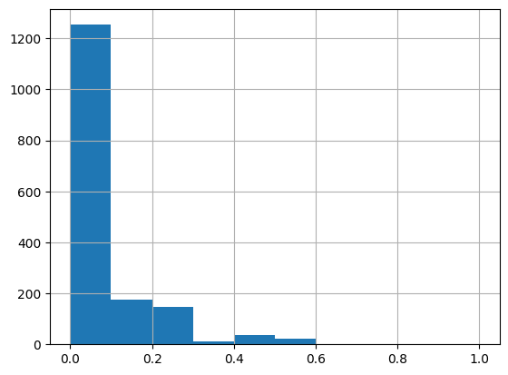

```python
y.hist()
```

Chia tập train, test với tỉ lệ 80/20, cố định `random_state = 0`

```python
X_train, X_test, y_train, y_test = train_test_split(X, y, test_size=0.2, random_state=0)
```

```python
y_train.info()
```

```
<class 'pandas.core.series.Series'>
Index: 1319 entries, 1537 to 1168
Series name: email_time_center
Non-Null Count  Dtype
--------------  -----
1319 non-null   float64
dtypes: float64(1)
memory usage: 20.6 KB
```

```python
def print_metrics(y_test, y_pred):
  mse = mean_squared_error(y_test, y_pred)
  rmse = np.sqrt(mse)
  r2 = r2_score(y_test, y_pred)

  # print(f'metrics, mse: {mse}, rmse: {rmse}, r2: {r2}')
  return {
    'mse': mse,
    'rmse': rmse,
    'r2': r2
  }
```

## Phân tích dữ liệu

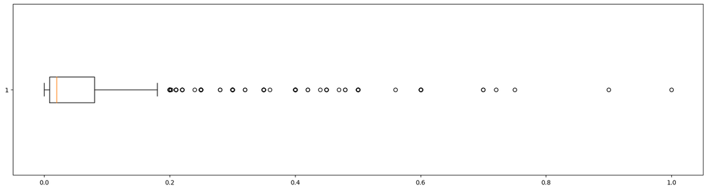

```python
plt.figure(figsize=(20, 5))
plt.boxplot(y, vert=False)
plt.show()
```

Có thể thấy dữ liệu email_time_center rất phân tán. Dữ liệu tập trung nhiều ở vùng giá trị thấp, hình ảnh right skewed rõ nét.

Ta xem thêm biểu đồ histogram về phân phối của dữ liệu:

```
(0.0, 100.0)
```

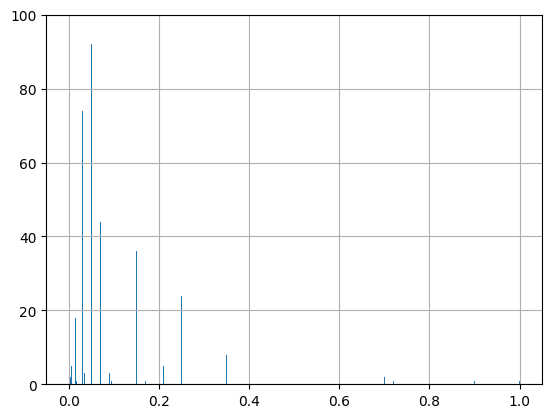

```python
y.hist(bins = 1300)
plt.ylim([0,100])
```

Có thể thấy, email_time_center là biến liên tục không âm, và có dáng điệu tương đối giống phân phối Gamma (ta có thể cộng thêm 1 hằng số dương để đảm bảo giá trị luôn dương).

Ta sẽ dùng biểu đồ QQplot để kiểm tra thêm việc này.

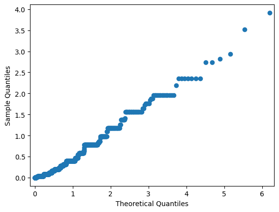

```python
y = pd.read_csv('data/preprocessing/y.csv')
qqplot(y['email_time_center'], gamma, fit=True)
plt.show()
```

phân bố của email_time_center khá khớp với phân bố Gamma

```
<class 'pandas.core.frame.DataFrame'>
Index: 1649 entries, 0 to 2865
Data columns (total 12 columns):
 #   Column             Non-Null Count  Dtype
---  ------             --------------  -----
 0   emailmin           1649 non-null   float64
 1   emailhr            1649 non-null   float64
 2   educ               1649 non-null   float64
 3   email_time         1649 non-null   float64
 4   email_time_center  1649 non-null   float64
 5   educ_center        1649 non-null   float64
 6   harass5            431 non-null    object
 7   polviews           1594 non-null   object
 8   advfront           1216 non-null   object
 9   snapchat           680 non-null    object
 10  instagrm           680 non-null    object
 11  wrkstat            1648 non-null   object
dtypes: float64(6), object(6)
memory usage: 167.5+ KB
```

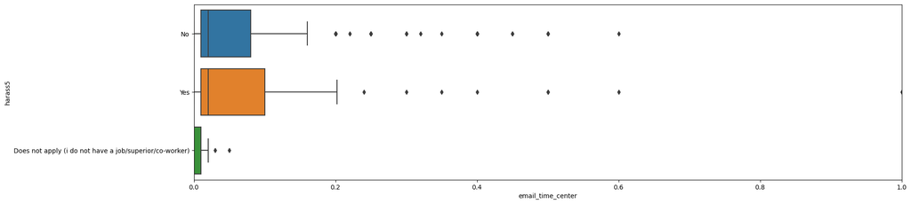

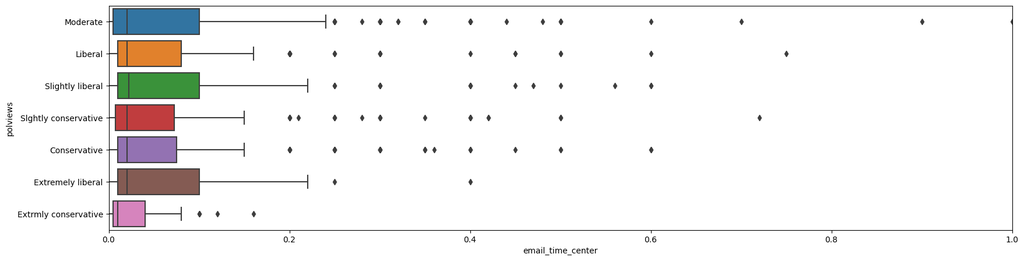

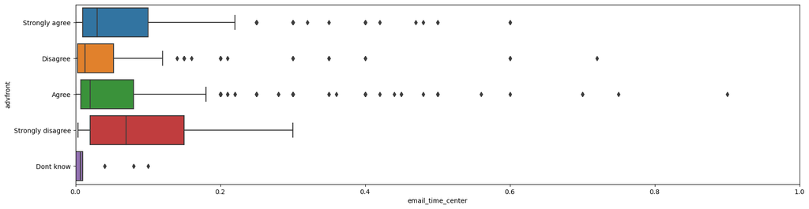

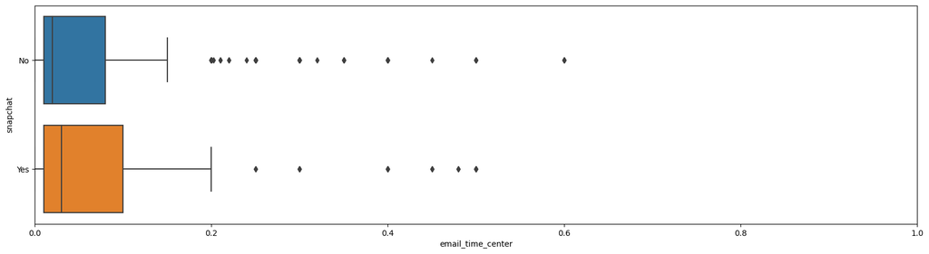

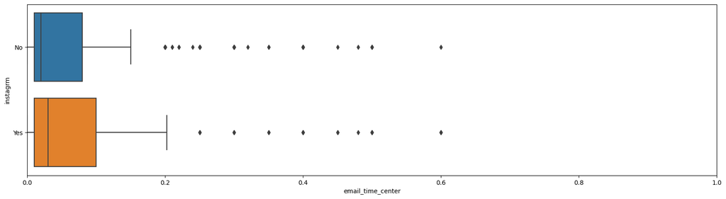

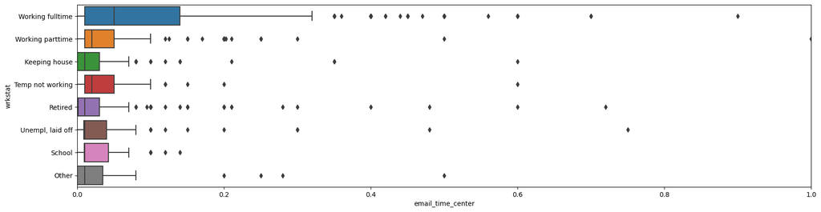

```python
import seaborn as sns

dat = pd.concat([df_num, df_cat], axis=1)

dat.info()

plt.figure(figsize=(20, 5))
sns.boxplot(data=dat, x="email_time_center", y="harass5")
plt.xlim([0, 1])
plt.show()

plt.figure(figsize=(20, 5))
sns.boxplot(data=dat, x="email_time_center", y="polviews")
plt.xlim([0, 1])
plt.show()

plt.figure(figsize=(20, 5))
sns.boxplot(data=dat, x="email_time_center", y="advfront")
plt.xlim([0, 1])
plt.show()

plt.figure(figsize=(20, 5))
sns.boxplot(data=dat, x="email_time_center", y="snapchat")
plt.xlim([0, 1])
plt.show()

plt.figure(figsize=(20, 5))
sns.boxplot(data=dat, x="email_time_center", y="instagrm")
plt.xlim([0, 1])
plt.show()

plt.figure(figsize=(20, 5))
sns.boxplot(data=dat, x="email_time_center", y="wrkstat")
plt.xlim([0, 1])
plt.show()
```

Tiếp theo, xem xét sự phụ thuộc của email_time_center đối với biến educ (biến dạng số duy nhất ở đây)

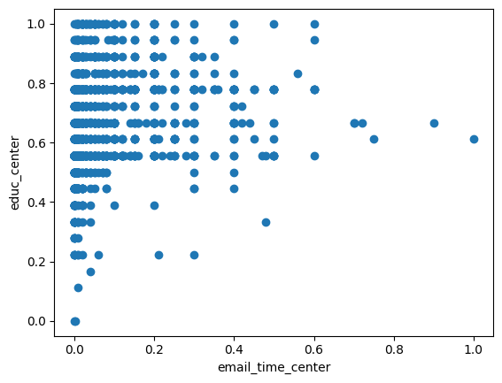

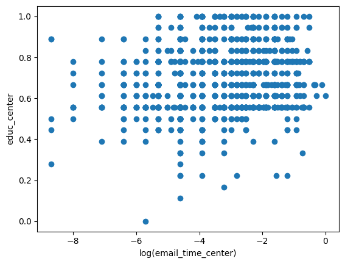

```python
plt.scatter(dat["email_time_center"], dat["educ_center"])
plt.xlabel("email_time_center")
plt.ylabel("educ_center")
plt.show()

plt.scatter(np.log(dat["email_time_center"]), dat["educ_center"])
plt.xlabel("log(email_time_center)")
plt.ylabel("educ_center")
plt.show()
```

Khá khó để đánh giá bằng mặt sự phụ thuộc của email_time_center vào biến educ_center nếu dựa vào các biểu đồ trên. Ở phần sau ta sẽ tìm kiếm các mô hình và phân tích định lượng để xem email_time_center phụ thuộc như thế nào vào các biến giải thích.

## Các mô hình tuyến tính

### Mô hình GLM

```python
X = pd.read_csv('data/preprocessing/X.csv')
y = pd.read_csv('data/preprocessing/y.csv')
```

Như nhận xét ở phần trước, ta thấy rằng biến đầu ra có dáng điệu của phân bố Gamma, ta sẽ thử xây dựng mô hình GLM với phân bố này. Trước hết, để tránh biến đầu ra có giá trị 0 (phân bố Gamma áp dụng cho biến đầu ra > 0) ta sẽ cộng một nhiễu nhỏ vào biến y.

```
array([[<Axes: title={'center': 'email_time_center'}>,
        <Axes: title={'center': 'noise'}>]], dtype=object)
```

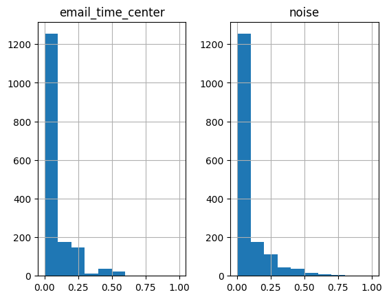

```python
sigma = 1e-3
y['noise'] = y['email_time_center'] + sigma
y.hist()
```

Chia lại train, test

```python
X_train, X_test, y_train, y_test = train_test_split(X, y['noise'], test_size=0.2, random_state=0)
```

Cấu hình mô hình GLM với link function là hàm `log`, thuật toán tối ưu là `lbfgs`

```python
link_function = stm.genmod.families.links.Log()
gamma_model = stm.api.GLM(y_train, X_train, family=stm.api.families.Gamma(link=link_function))
gamma_results = gamma_model.fit(method='lbfgs')
gamma_results.summary()
```

Generalized Linear Model Regression Results

| Dep. Variable: | noise | No. Observations: | 1319 |
| --- | --- | --- | --- |
| Model: | GLM | Df Residuals: | 1292 |
| Model Family: | Gamma | Df Model: | 26 |
| Link Function: | Log | Scale: | 2.7225 |
| Method: | lbfgs | Log-Likelihood: | 2446.1 |
| Date: | Tue, 15 Aug 2023 | Deviance: | 2766.4 |
| Time: | 16:45:46 | Pearson chi2: | 3.52e+03 |
| No. Iterations: | 76 | Pseudo R-squ. (CS): | 0.1155 |
| Covariance Type: | nonrobust |  |  |

|  | coef | std err | z | P>\|z\| | [0.025 | 0.975] |
| --- | --- | --- | --- | --- | --- | --- |
| educ_center | 1.7498 | 0.336 | 5.207 | 0.000 | 1.091 | 2.409 |
| harass5_Does_not_apply_(i_do_not_have_a_job/superior/co-worker) | 0.5757 | 1.705 | 0.338 | 0.736 | -2.767 | 3.918 |
| harass5_No | 1.6434 | 1.659 | 0.991 | 0.322 | -1.608 | 4.895 |
| harass5_Yes | 2.1376 | 1.672 | 1.279 | 0.201 | -1.139 | 5.414 |
| polviews_Conservative | -0.3103 | 0.287 | -1.081 | 0.280 | -0.873 | 0.252 |
| polviews_Extremely_liberal | -0.3731 | 0.339 | -1.100 | 0.272 | -1.038 | 0.292 |
| polviews_Extrmly_conservative | -0.8881 | 0.349 | -2.546 | 0.011 | -1.572 | -0.205 |
| polviews_Liberal | -0.4096 | 0.292 | -1.402 | 0.161 | -0.982 | 0.163 |
| polviews_Moderate | -0.2551 | 0.267 | -0.956 | 0.339 | -0.778 | 0.268 |
| polviews_Slghtly_conservative | -0.4439 | 0.287 | -1.550 | 0.121 | -1.005 | 0.118 |
| polviews_Slightly_liberal | -0.2263 | 0.294 | -0.771 | 0.441 | -0.802 | 0.349 |
| advfront_Agree | 1.8392 | 1.659 | 1.109 | 0.268 | -1.412 | 5.090 |
| advfront_Disagree | 2.0708 | 1.664 | 1.244 | 0.213 | -1.191 | 5.333 |
| advfront_Dont_know | 1.3055 | 1.719 | 0.760 | 0.448 | -2.063 | 4.674 |
| advfront_Strongly_agree | 1.8806 | 1.660 | 1.133 | 0.257 | -1.373 | 5.134 |
| advfront_Strongly_disagree | 2.8589 | 1.790 | 1.597 | 0.110 | -0.650 | 6.368 |
| snapchat_No | -0.0356 | 5.93e+06 | -6e-09 | 1.000 | -1.16e+07 | 1.16e+07 |
| snapchat_Yes | 0.2510 | 5.93e+06 | 4.23e-08 | 1.000 | -1.16e+07 | 1.16e+07 |
| instagrm_No | 0.1412 | 5.93e+06 | 2.38e-08 | 1.000 | -1.16e+07 | 1.16e+07 |
| instagrm_Yes | 0.0742 | 5.93e+06 | 1.25e-08 | 1.000 | -1.16e+07 | 1.16e+07 |
| wrkstat_Keeping_house | -6.3681 | 1.692 | -3.764 | 0.000 | -9.684 | -3.053 |
| wrkstat_Other | -5.7151 | 1.727 | -3.308 | 0.001 | -9.101 | -2.329 |
| wrkstat_Retired | -5.9808 | 1.692 | -3.534 | 0.000 | -9.297 | -2.664 |
| wrkstat_School | -6.1987 | 1.709 | -3.628 | 0.000 | -9.547 | -2.850 |
| wrkstat_Temp_not_working | -5.6451 | 1.722 | -3.278 | 0.001 | -9.021 | -2.269 |
| wrkstat_Unempl,_laid_off | -5.5115 | 1.698 | -3.246 | 0.001 | -8.840 | -2.183 |
| wrkstat_Working_fulltime | -5.1353 | 1.689 | -3.040 | 0.002 | -8.446 | -1.825 |
| wrkstat_Working_parttime | -5.7987 | 1.681 | -3.449 | 0.001 | -9.094 | -2.504 |

```python
y_pred = gamma_results.predict(X_test)
print_metrics(y_test, y_pred)
```

```
{'mse': 0.00901724897484081,
 'rmse': 0.094959196367918,
 'r2': 0.08931380081135276}
```

```python
choices = ['educ_center', 'wrkstat_Keeping_house', 'wrkstat_Other', 'wrkstat_Retired', 'wrkstat_School', 'wrkstat_Temp_not_working', 'wrkstat_Unempl,_laid_off', 'wrkstat_Working_fulltime', 'wrkstat_Working_parttime']
X_train_choice = X_train[X_train.columns.intersection(choices)]
X_test_choice = X_test[X_test.columns.intersection(choices)]
```

Xây dựng lại mô hình với các biến giải thích được chọn

```python
link_function = stm.genmod.families.links.Log()
gm_model = stm.api.GLM(y_train, X_train_choice, family=stm.api.families.Gamma(link=link_function))
gm_res = gm_model.fit(method='lbfgs')
gm_res.summary()
```

Generalized Linear Model Regression Results

| Dep. Variable: | noise | No. Observations: | 1319 |
| --- | --- | --- | --- |
| Model: | GLM | Df Residuals: | 1310 |
| Model Family: | Gamma | Df Model: | 8 |
| Link Function: | Log | Scale: | 3.1713 |
| Method: | lbfgs | Log-Likelihood: | 2367.1 |
| Date: | Tue, 15 Aug 2023 | Deviance: | 2861.4 |
| Time: | 16:45:46 | Pearson chi2: | 4.15e+03 |
| No. Iterations: | 16 | Pseudo R-squ. (CS): | 0.07930 |
| Covariance Type: | nonrobust |  |  |

|  | coef | std err | z | P>\|z\| | [0.025 | 0.975] |
| --- | --- | --- | --- | --- | --- | --- |
| educ_center | 1.4805 | 0.331 | 4.476 | 0.000 | 0.832 | 2.129 |
| wrkstat_Keeping_house | -4.5508 | 0.267 | -17.043 | 0.000 | -5.074 | -4.027 |
| wrkstat_Other | -3.9870 | 0.418 | -9.535 | 0.000 | -4.807 | -3.167 |
| wrkstat_Retired | -4.2569 | 0.241 | -17.699 | 0.000 | -4.728 | -3.786 |
| wrkstat_School | -4.4415 | 0.356 | -12.479 | 0.000 | -5.139 | -3.744 |
| wrkstat_Temp_not_working | -3.8865 | 0.416 | -9.342 | 0.000 | -4.702 | -3.071 |
| wrkstat_Unempl,_laid_off | -3.7014 | 0.319 | -11.608 | 0.000 | -4.326 | -3.076 |
| wrkstat_Working_fulltime | -3.3562 | 0.241 | -13.943 | 0.000 | -3.828 | -2.884 |
| wrkstat_Working_parttime | -3.9947 | 0.258 | -15.489 | 0.000 | -4.500 | -3.489 |

```python
y_pred = gm_res.predict(X_test_choice)
print_metrics(y_test, y_pred)
```

```
{'mse': 0.008810617366608622,
 'rmse': 0.09386488889147326,
 'r2': 0.11018231120274202}
```

Ta thử đưa vào hàm phạt với hiệu chỉnh L1, L2 với các tỉ lệ khác nhau

```python
results = []
for al in np.arange(0, 1, 0.05, dtype=float):
  link_function = stm.genmod.families.links.Log()
  gm_pn_model = stm.api.GLM(y_train, X_train_choice, family=stm.api.families.Gamma(link=link_function))
  gm_pn_res = gm_pn_model.fit_regularized(method='elastic_net', alpha=al, opt_method='bfgs')
  y_pred = gm_pn_res.predict(X_test_choice)
  res = print_metrics(y_test, y_pred)
  if res.get('r2') > 0:
    results.append([al, res])
print(results)
```

```
[[0.0, {'mse': 0.00887307113577514, 'rmse': 0.0941969805024298, 'r2': 0.10387486800959611}]]
```

`{'mse': 0.00887307113577514, 'rmse': 0.0941969805024298, 'r2': 0.10387486800959611}`

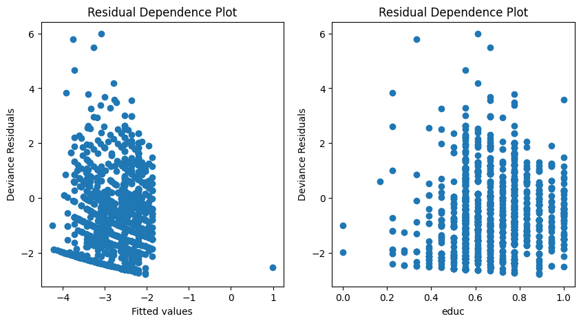

```python
resid = gm_res.resid_deviance

fig, ax = plt.subplots(1, 2, figsize=(10,5))

ax[0].scatter(np.log(gm_res.mu), resid)
ax[0].set_title('Residual Dependence Plot')
ax[0].set_ylabel('Deviance Residuals')
ax[0].set_xlabel('Fitted values')

ax[1].scatter(X_train['educ_center'], resid)
ax[1].set_title('Residual Dependence Plot')
ax[1].set_ylabel('Deviance Residuals')
ax[1].set_xlabel('educ')
plt.show()
```

Phân bố của phần dư tương đối ngẫu nhiên qua trục 0.

Ta tiếp tục kiểm tra phân phối chuẩn của phần dư bằng biểu đồ `QQplot`

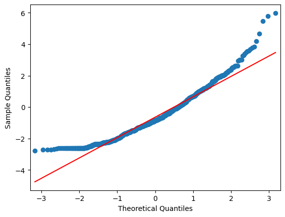

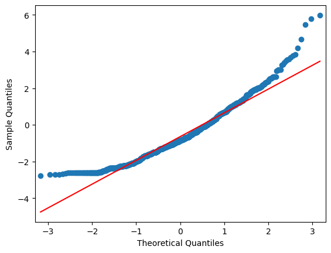

```python
from statsmodels import graphics
graphics.gofplots.qqplot(resid, line='r')
```

**Các điểm Infuence** Trong phần này, chúng ta thử đi tìm các điểm dữ liệu outlier và đánh giá xem chúng có ảnh hưởng như thế nào đến mô hình

Các điểm influence là các điểm không tuân theo xu hướng chung của các điểm khác trong tập dữ liệu (outlier) và ảnh hưởng nghiêm trọng đến mô hình. Nó là các điểm có phần dư lớn và giá trị đòn bẩy (leverage) lớn.

Vì các điểm này không thể hiện xu hướng chung của dữ liệu, nó gây nhiễu cho mô hình. Mục tiêu của ta làm tìm các điểm này và loại nó khỏi dữ liệu train, sau đó fit lại để có mô hình tốt hơn.

Các điểm Influence được đánh giá qua giá trị Cook's distance. Ta lấy thử ra 10 điểm có Cook's distance lớn nhất.

```python
infl = gm_res.get_influence()

summ_df = infl.summary_frame()

outlier_df = summ_df[["cooks_d", "standard_resid", "hat_diag", "dffits_internal"]].sort_values("cooks_d", ascending=False)[:10]
outlier_df
```

|  | cooks_d | standard_resid | hat_diag | dffits_internal |
| --- | --- | --- | --- | --- |
| 862 | 4.035186 | 6.799746 | 0.439918 | 6.026332 |
| 742 | 2.945102 | 12.047691 | 0.154416 | 5.148390 |
| 1356 | 2.848822 | 12.694681 | 0.137260 | 5.063536 |
| 149 | 1.765642 | 7.247217 | 0.232277 | 3.986324 |
| 1352 | 1.648737 | 5.623158 | 0.319395 | 3.852095 |
| 1232 | 1.101235 | 10.531285 | 0.082033 | 3.148193 |
| 553 | 1.092000 | 8.180793 | 0.128046 | 3.134964 |
| 1357 | 0.467614 | 3.351582 | 0.272544 | 2.051470 |
| 1393 | 0.464466 | 4.638673 | 0.162669 | 2.044552 |
| 1313 | 0.455841 | 5.782726 | 0.109278 | 2.025481 |

```python
outlier = outlier_df.index.values.tolist()
# X_train.loc[outlier]
```

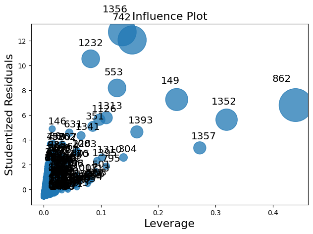

```python
fig = infl.plot_influence()
fig.tight_layout(pad=1.0)
```

Ta loại bỏ các quan sát có Cook's lớn nhất này và fit lại mô hình, quan sát lại các thông tin đánh giá về residual và phân phối của nó

```python
X_train_outlier = X_train.index.isin(outlier)
X_train_dr = X_train[~X_train_outlier]
y_train_dr = y_train[~X_train_outlier]
```

```python
X_train_dr.shape
```

```
(1309, 28)
```

```python
choices = ['educ_center', 'wrkstat_Keeping_house', 'wrkstat_Other', 'wrkstat_Retired', 'wrkstat_School', 'wrkstat_Temp_not_working', 'wrkstat_Unempl,_laid_off', 'wrkstat_Working_fulltime', 'wrkstat_Working_parttime']
X_train_dr_choice = X_train_dr[X_train_dr.columns.intersection(choices)]
X_test_dr_choice = X_test[X_test.columns.intersection(choices)]

link_function = stm.genmod.families.links.Log()
gm_ol_model = stm.api.GLM(y_train_dr, X_train_dr_choice, family=stm.api.families.Gamma(link=link_function))
gm_ol_res = gm_ol_model.fit(method='lbfgs')
gm_ol_res.summary()
```

Generalized Linear Model Regression Results

| Dep. Variable: | noise | No. Observations: | 1309 |
| --- | --- | --- | --- |
| Model: | GLM | Df Residuals: | 1300 |
| Model Family: | Gamma | Df Model: | 8 |
| Link Function: | Log | Scale: | 2.2591 |
| Method: | lbfgs | Log-Likelihood: | 2546.2 |
| Date: | Tue, 15 Aug 2023 | Deviance: | 2608.1 |
| Time: | 16:45:48 | Pearson chi2: | 2.94e+03 |
| No. Iterations: | 14 | Pseudo R-squ. (CS): | 0.1568 |
| Covariance Type: | nonrobust |  |  |

|  | coef | std err | z | P>\|z\| | [0.025 | 0.975] |
| --- | --- | --- | --- | --- | --- | --- |
| educ_center | 2.0816 | 0.291 | 7.145 | 0.000 | 1.511 | 2.653 |
| wrkstat_Keeping_house | -5.0616 | 0.232 | -21.793 | 0.000 | -5.517 | -4.606 |
| wrkstat_Other | -5.4834 | 0.375 | -14.620 | 0.000 | -6.219 | -4.748 |
| wrkstat_Retired | -4.8993 | 0.221 | -22.165 | 0.000 | -5.333 | -4.466 |
| wrkstat_School | -4.8171 | 0.304 | -15.866 | 0.000 | -5.412 | -4.222 |
| wrkstat_Temp_not_working | -4.6850 | 0.356 | -13.142 | 0.000 | -5.384 | -3.986 |
| wrkstat_Unempl,_laid_off | -4.5441 | 0.279 | -16.286 | 0.000 | -5.091 | -3.997 |
| wrkstat_Working_fulltime | -3.7716 | 0.208 | -18.139 | 0.000 | -4.179 | -3.364 |
| wrkstat_Working_parttime | -4.5276 | 0.222 | -20.370 | 0.000 | -4.963 | -4.092 |

```python
y_pred = gm_ol_res.predict(X_test_choice)
print_metrics(y_test, y_pred)
```

```
{'mse': 0.008855304985080597,
 'rmse': 0.09410263006462995,
 'r2': 0.10566913900015762}
```

Kết quả không khác biệt nhiều, tác động của outlier ở đây không đáng kể lắm. Thậm chí việc bỏ đi các điểm được coi là outlier còn làm mô hình tệ đi.

### Mô hình GAM

Mô hình hồi quy cộng tính tổng quát (GAM - Generalized Additive Models) là trường hợp tổng quát hơn của GLM. GAM cố gắng mô hình hóa cả tác động của các biến độc lập mà có quan hệ phi tuyến với biến phụ thuộc.

Công thức tổng quát của GAM:

$g(\mu) = \sum_{k} \alpha_k X_k + \sum_{j} s_j(Z_j)$

Trong đó:

- $\mu=E(Y)$ với $Y$ là biến phụ thuộc có phân phối họ mũ
- $X_k$ là các biến độc lập có tác động tuyến tính đến biến phụ thuộc, các hệ số $\alpha_k$ chưa biết.
- $Z_j$ là các biến độc lập có tác động phi tuyến đến biến phụ thuộc, $s_j(.)$ là hàm trơn (spline)
- $g(.)$ là link function

GAM được ước lượng bằng phương pháp hợp lý cực đại có phạt, trong đó các hàm trơn được ước lượng qua các spline và nút.

Đầu tiên ta thử fit mô hình với tất cả các biến mà GLM đã chọn ở trên. Các tham số của GAM cần chọn:

- degree: bậc của hàm trong 1 đoạn spline
- df (degree of freedom): số bậc tự do của spline
- alpha: hệ số phạt

Trước hết ta thử huấn luyện mô hình với tất cả các thuộc tính

```python
x_spline = X_train["educ_center"]
bs = stm.gam.api.BSplines(x_spline, df=8, degree=3)

X_train_wt_educ = X_train[X_train.columns.difference(['educ_center'])]
X_test_wt_educ = X_test[X_test.columns.difference(['educ_center'])]

alpha = 10
gam_bs = stm.gam.api.GLMGam(y_train, X_train_wt_educ, alpha=alpha, smoother=bs, family=sm.families.Gamma(link=sm.families.links.Log()))
fitted_gam = gam_bs.fit()
fitted_gam.summary()
```

Generalized Linear Model Regression Results

| Dep. Variable: | noise | No. Observations: | 1319 |
| --- | --- | --- | --- |
| Model: | GLMGam | Df Residuals: | 1292.55 |
| Model Family: | Gamma | Df Model: | 25.45 |
| Link Function: | Log | Scale: | 2.7201 |
| Method: | PIRLS | Log-Likelihood: | 2446.5 |
| Date: | Tue, 15 Aug 2023 | Deviance: | 2765.8 |
| Time: | 16:45:49 | Pearson chi2: | 3.52e+03 |
| No. Iterations: | 42 | Pseudo R-squ. (CS): | 0.1157 |
| Covariance Type: | nonrobust |  |  |

|  | coef | std err | z | P>\|z\| | [0.025 | 0.975] |
| --- | --- | --- | --- | --- | --- | --- |
| advfront_Agree | 1.8387 | 0.972 | 1.891 | 0.059 | -0.067 | 3.744 |
| advfront_Disagree | 2.0712 | 0.972 | 2.131 | 0.033 | 0.166 | 3.976 |
| advfront_Dont_know | 1.3040 | 1.081 | 1.206 | 0.228 | -0.814 | 3.422 |
| advfront_Strongly_agree | 1.8806 | 0.975 | 1.929 | 0.054 | -0.030 | 3.791 |
| advfront_Strongly_disagree | 2.8598 | 1.176 | 2.431 | 0.015 | 0.554 | 5.166 |
| harass5_Does_not_apply_(i_do_not_have_a_job/superior/co-worker) | 0.5753 | 1.047 | 0.550 | 0.583 | -1.476 | 2.627 |
| harass5_No | 1.6428 | 0.974 | 1.686 | 0.092 | -0.267 | 3.553 |
| harass5_Yes | 2.1372 | 1.000 | 2.138 | 0.033 | 0.178 | 4.097 |
| instagrm_No | 0.1417 | 2.4e+05 | 5.89e-07 | 1.000 | -4.71e+05 | 4.71e+05 |
| instagrm_Yes | 0.0744 | 2.4e+05 | 3.09e-07 | 1.000 | -4.71e+05 | 4.71e+05 |
| polviews_Conservative | -0.3104 | 0.271 | -1.145 | 0.252 | -0.842 | 0.221 |
| polviews_Extremely_liberal | -0.3729 | 0.327 | -1.140 | 0.254 | -1.014 | 0.268 |
| polviews_Extrmly_conservative | -0.8880 | 0.341 | -2.605 | 0.009 | -1.556 | -0.220 |
| polviews_Liberal | -0.4095 | 0.278 | -1.472 | 0.141 | -0.955 | 0.136 |
| polviews_Moderate | -0.2554 | 0.255 | -1.002 | 0.316 | -0.755 | 0.244 |
| polviews_Slghtly_conservative | -0.4443 | 0.273 | -1.628 | 0.103 | -0.979 | 0.090 |
| polviews_Slightly_liberal | -0.2268 | 0.281 | -0.807 | 0.420 | -0.777 | 0.324 |
| snapchat_No | -0.0357 | 2.4e+05 | -1.49e-07 | 1.000 | -4.71e+05 | 4.71e+05 |
| snapchat_Yes | 0.2516 | 2.4e+05 | 1.05e-06 | 1.000 | -4.71e+05 | 4.71e+05 |
| wrkstat_Keeping_house | -6.3757 | 0.990 | -6.439 | 0.000 | -8.316 | -4.435 |
| wrkstat_Other | -5.7226 | 1.038 | -5.515 | 0.000 | -7.756 | -3.689 |
| wrkstat_Retired | -5.9878 | 0.987 | -6.064 | 0.000 | -7.923 | -4.053 |
| wrkstat_School | -6.2067 | 1.020 | -6.088 | 0.000 | -8.205 | -4.208 |
| wrkstat_Temp_not_working | -5.6520 | 1.031 | -5.483 | 0.000 | -7.672 | -3.632 |
| wrkstat_Unempl,_laid_off | -5.5194 | 1.005 | -5.492 | 0.000 | -7.489 | -3.550 |
| wrkstat_Working_fulltime | -5.1428 | 0.983 | -5.231 | 0.000 | -7.070 | -3.216 |
| wrkstat_Working_parttime | -5.8062 | 0.985 | -5.896 | 0.000 | -7.736 | -3.876 |
| educ_center_s0 | 0.3259 | 0.077 | 4.236 | 0.000 | 0.175 | 0.477 |
| educ_center_s1 | 0.6835 | 0.151 | 4.517 | 0.000 | 0.387 | 0.980 |
| educ_center_s2 | 1.1112 | 0.217 | 5.117 | 0.000 | 0.686 | 1.537 |
| educ_center_s3 | 1.2414 | 0.237 | 5.228 | 0.000 | 0.776 | 1.707 |
| educ_center_s4 | 1.4664 | 0.273 | 5.376 | 0.000 | 0.932 | 2.001 |
| educ_center_s5 | 1.6246 | 0.298 | 5.448 | 0.000 | 1.040 | 2.209 |
| educ_center_s6 | 1.7515 | 0.319 | 5.484 | 0.000 | 1.126 | 2.377 |

```python
y_pred = fitted_gam.predict(exog=X_test_wt_educ, exog_smooth=X_test['educ_center'])
print_metrics(y_test, y_pred)
```

```
{'mse': 0.00901438641701245,
 'rmse': 0.0949441226038371,
 'r2': 0.08960290139135685}
```

```python
x_spline = X_train["educ_center"]
bs = stm.gam.api.BSplines(x_spline, df=8, degree=3)

X_train_choice_wt_educ = X_train_choice[X_train_choice.columns.difference(['educ_center'])]
X_test_choice_wt_educ = X_test_choice[X_test_choice.columns.difference(['educ_center'])]

alpha = 10
gam_bs = stm.gam.api.GLMGam(y_train, X_train_choice_wt_educ, alpha=alpha, smoother=bs, family=sm.families.Gamma(link=sm.families.links.Log()))
fitted_gam = gam_bs.fit()
fitted_gam.summary()
```

Generalized Linear Model Regression Results

| Dep. Variable: | noise | No. Observations: | 1319 |
| --- | --- | --- | --- |
| Model: | GLMGam | Df Residuals: | 1310.00 |
| Model Family: | Gamma | Df Model: | 8.00 |
| Link Function: | Log | Scale: | 3.1711 |
| Method: | PIRLS | Log-Likelihood: | 2367.2 |
| Date: | Tue, 15 Aug 2023 | Deviance: | 2861.0 |
| Time: | 16:45:49 | Pearson chi2: | 4.15e+03 |
| No. Iterations: | 10 | Pseudo R-squ. (CS): | 0.07938 |
| Covariance Type: | nonrobust |  |  |

|  | coef | std err | z | P>\|z\| | [0.025 | 0.975] |
| --- | --- | --- | --- | --- | --- | --- |
| wrkstat_Keeping_house | -4.5498 | 0.272 | -16.710 | 0.000 | -5.083 | -4.016 |
| wrkstat_Other | -3.9859 | 0.426 | -9.360 | 0.000 | -4.821 | -3.151 |
| wrkstat_Retired | -4.2557 | 0.262 | -16.242 | 0.000 | -4.769 | -3.742 |
| wrkstat_School | -4.4407 | 0.369 | -12.033 | 0.000 | -5.164 | -3.717 |
| wrkstat_Temp_not_working | -3.8853 | 0.410 | -9.483 | 0.000 | -4.688 | -3.082 |
| wrkstat_Unempl,_laid_off | -3.7004 | 0.333 | -11.098 | 0.000 | -4.354 | -3.047 |
| wrkstat_Working_fulltime | -3.3554 | 0.251 | -13.373 | 0.000 | -3.847 | -2.864 |
| wrkstat_Working_parttime | -3.9938 | 0.267 | -14.933 | 0.000 | -4.518 | -3.470 |
| educ_center_s0 | 0.2728 | 0.081 | 3.369 | 0.001 | 0.114 | 0.431 |
| educ_center_s1 | 0.5708 | 0.159 | 3.597 | 0.000 | 0.260 | 0.882 |
| educ_center_s2 | 0.9321 | 0.226 | 4.125 | 0.000 | 0.489 | 1.375 |
| educ_center_s3 | 1.0424 | 0.247 | 4.226 | 0.000 | 0.559 | 1.526 |
| educ_center_s4 | 1.2334 | 0.283 | 4.362 | 0.000 | 0.679 | 1.788 |
| educ_center_s5 | 1.3680 | 0.309 | 4.431 | 0.000 | 0.763 | 1.973 |
| educ_center_s6 | 1.4759 | 0.330 | 4.466 | 0.000 | 0.828 | 2.124 |

```python
y_pred = fitted_gam.predict(exog=X_test_choice_wt_educ, exog_smooth=X_test['educ_center'])
print_metrics(y_test, y_pred)
```

```
{'mse': 0.008808015983073438,
 'rmse': 0.09385103080453319,
 'r2': 0.11044503479958379}
```

Giá trị r2 tốt hơn khoảng $23\%$

### Mô hình GLM với Bayes

Định nghĩa function huấn luyện và đánh giá mô hình

```python
def final_model(X_train, y_train, X_test, y_test):
    X_train["email_time_center"] = pd.Series(y_train)
    X_test["email_time_center"] = pd.Series(y_test)
    model = bmb.Model(
        """email_time_center ~ educ_center + wrkstat_Working_fulltime""",
        X_train, dropna=True, family="gamma", link="log")
    print(model)

    _, ax = plt.subplots(1, 1, sharex=True, sharey=True, figsize=(6, 6))
    ax.set_xlim(xmin=0, xmax=1)
    ax.set_ylim(ymin=0, ymax=1)

    results = model.fit(draws=1000, chains=2, random_seed=0)
    print(az.summary(results))

    # Diagnostics
    model.predict(results, data=X_test, kind="pps")
    az.plot_ppc(results, ax=ax)

    # predict
    model.predict(results, data=X_test, kind="mean")
    print(results.posterior)
    y_predict = np.array(results.posterior.email_time_center_mean[0, 0, :])
    print(y_predict.shape)

    mse = mean_squared_error(y_test, y_predict)
    rmse = mean_squared_error(y_test, y_predict, squared=False)
    r2 = r2_score(y_test, y_predict)
    print(f"Test MSE: {mse}")
    print(f"Test RMSE: {rmse}")
    print(f'Test R2 score: {r2}')
```

```
Index(['educ_center',
       'harass5_Does_not_apply_(i_do_not_have_a_job/superior/co-worker)',
       'harass5_No', 'harass5_Yes', 'polviews_Conservative',
       'polviews_Extremely_liberal', 'polviews_Extrmly_conservative',
       'polviews_Liberal', 'polviews_Moderate',
       'polviews_Slghtly_conservative', 'polviews_Slightly_liberal',
       'advfront_Agree', 'advfront_Disagree', 'advfront_Dont_know',
       'advfront_Strongly_agree', 'advfront_Strongly_disagree', 'snapchat_No',
       'snapchat_Yes', 'instagrm_No', 'instagrm_Yes', 'wrkstat_Keeping_house',
       'wrkstat_Other', 'wrkstat_Retired', 'wrkstat_School',
       'wrkstat_Temp_not_working', 'wrkstat_Unempl,_laid_off',
       'wrkstat_Working_fulltime', 'wrkstat_Working_parttime'],
      dtype='object')
       Formula: email_time_center ~ educ_center + wrkstat_Working_fulltime
        Family: gamma
          Link: mu = log
  Observations: 1319
        Priors:
    target = mu
        Common-level effects
            Intercept ~ Normal(mu: 0.0, sigma: 11.3625)
            educ_center ~ Normal(mu: 0.0, sigma: 16.1277)
            wrkstat_Working_fulltime ~ Normal(mu: 0.0, sigma: 5.0001)

        Auxiliary parameters
            alpha ~ HalfCauchy(beta: 1.0)
```

```
Auto-assigning NUTS sampler...
Initializing NUTS using jitter+adapt_diag...
Multiprocess sampling (2 chains in 4 jobs)
NUTS: [email_time_center_alpha, Intercept, educ_center, wrkstat_Working_fulltime]
```

100.00% [4000/4000 00:01<00:00 Sampling 2 chains, 0 divergences]

```
Sampling 2 chains for 1_000 tune and 1_000 draw iterations (2_000 + 2_000 draws total) took 2 seconds.
We recommend running at least 4 chains for robust computation of convergence diagnostics
```

```
                           mean     sd  hdi_3%  hdi_97%  mcse_mean  mcse_sd
Intercept                -4.184  0.160  -4.465   -3.879      0.003    0.002  \
educ_center               1.534  0.237   1.118    2.020      0.004    0.003
wrkstat_Working_fulltime  0.792  0.076   0.652    0.938      0.001    0.001
email_time_center_alpha   0.567  0.019   0.532    0.602      0.000    0.000

                          ess_bulk  ess_tail  r_hat
Intercept                   3910.0    1791.0    1.0
educ_center                 3551.0    1868.0    1.0
wrkstat_Working_fulltime    3439.0    1644.0    1.0
email_time_center_alpha     3181.0    1494.0    1.0
<xarray.Dataset>
Dimensions:                   (chain: 2, draw: 1000, email_time_center_obs: 330)
Coordinates:
  * chain                     (chain) int64 0 1
  * draw                      (draw) int64 0 1 2 3 4 5 ... 995 996 997 998 999
  * email_time_center_obs     (email_time_center_obs) int64 0 1 2 ... 328 329
Data variables:
    Intercept                 (chain, draw) float64 -4.085 -4.049 ... -4.09
    educ_center               (chain, draw) float64 1.435 1.346 ... 1.616 1.255
    wrkstat_Working_fulltime  (chain, draw) float64 0.7468 0.8603 ... 0.9201
    email_time_center_alpha   (chain, draw) float64 0.5801 0.5599 ... 0.6085
    email_time_center_mean    (chain, draw, email_time_center_obs) float64 0....
Attributes:
    created_at:                  2023-08-15T09:45:53.161709
    arviz_version:               0.15.1
    inference_library:           pymc
    inference_library_version:   5.6.1
    sampling_time:               1.736915111541748
    tuning_steps:                1000
    modeling_interface:          bambi
    modeling_interface_version:  0.12.0
(330,)
Test MSE: 0.008768820576340097
Test RMSE: 0.0936419808437439
Test R2 score: 0.11440352769284112
```

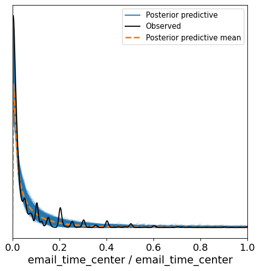

```python
noise = 0.001
X_bglm = pd.read_csv("data/preprocessing/X.csv")
y_bglm = pd.read_csv("data/preprocessing/y.csv")["email_time_center"].apply(lambda x: x+noise)
f = lambda x: re.sub(' ','_', x, flags = re.IGNORECASE)
X_bglm.rename(columns = f, inplace = True)
print(X.columns)
X_train_bglm, X_test_bglm, y_train_bglm, y_test_bglm = train_test_split(X_bglm, y_bglm, test_size=0.2, random_state=0)
final_model(X_train_bglm, y_train_bglm, X_test_bglm, y_test_bglm)
```

## Mô hình Random forest

Ta thực hiện các công việc sau:

- Đọc các tập dữ liệu, sử dụng thư viện Pandas
- Chia tập dữ liệu ban đầu thành các tập train, validation và test.
- Thực hiện việc xây dựng mô hình RandomForest trên tập train và tính toán feature importance trên tập validation để tìm ra các thuộc tính có ảnh hưởng đến mô hình.
- Vẽ biểu đồ từ giá trị feature importance.

```
educ_center                                                        0
harass5_Does_not_apply_(i_do_not_have_a_job/superior/co-worker)    0
harass5_No                                                         0
harass5_Yes                                                        0
polviews_Conservative                                              0
polviews_Extremely_liberal                                         0
polviews_Extrmly_conservative                                      0
polviews_Liberal                                                   0
polviews_Moderate                                                  0
polviews_Slghtly_conservative                                      0
polviews_Slightly_liberal                                          0
advfront_Agree                                                     0
advfront_Disagree                                                  0
advfront_Dont_know                                                 0
advfront_Strongly_agree                                            0
advfront_Strongly_disagree                                         0
snapchat_No                                                        0
snapchat_Yes                                                       0
instagrm_No                                                        0
instagrm_Yes                                                       0
wrkstat_Keeping_house                                              0
wrkstat_Other                                                      0
wrkstat_Retired                                                    0
wrkstat_School                                                     0
wrkstat_Temp_not_working                                           0
wrkstat_Unempl,_laid_off                                           0
wrkstat_Working_fulltime                                           0
wrkstat_Working_parttime                                           0
dtype: int64
```

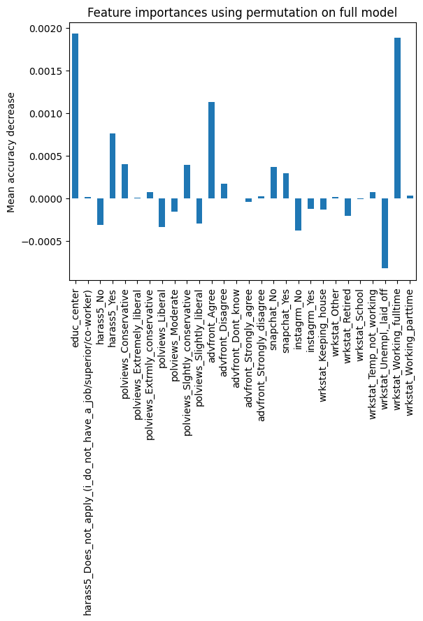

```python
from sklearn.ensemble import RandomForestRegressor, RandomForestClassifier
from sklearn.inspection import permutation_importance

X = pd.read_csv("data/preprocessing/X.csv")
y = pd.read_csv("data/preprocessing/y.csv")["email_time_center"]
X_train, X_test, y_train, y_test = train_test_split(X, y, random_state=0)
X_train_2, X_val, y_train_2, y_val = train_test_split(X_train, y_train, test_size=0.2, random_state=0)
print(X_train.isna().sum())

result_df = pd.DataFrame()

feature_names = list(X_train.columns)
forest = RandomForestRegressor(random_state=0)
forest.fit(X_train_2, y_train_2)

result = permutation_importance(
    forest, X_val, y_val, n_repeats=10, random_state=0, n_jobs=2,
    scoring=make_scorer(mean_squared_error, greater_is_better=False)
)

forest_importances = pd.Series(result.importances_mean, index=feature_names)

# Vẽ biểu đồ với cột tìm được.
fig, ax = plt.subplots()
forest_importances.plot.bar(ax=ax)
ax.set_title("Feature importances using permutation on full model")
ax.set_ylabel("Mean accuracy decrease")
fig.tight_layout()
plt.show()
```

Qua đây, chúng ta tìm được các feature dưới đây có ảnh hưởng đến mô hình.

- wrkstat_Working_fulltime
- educ_center
- harass5_Yes
- polviews_Slghtly_conservative
- advfront_Agree

Tiếp theo, chúng ta xây dựng lại mô hình RandomForest, chỉ sử dụng các feature này và đi tìm tham số tối ưu cho mô hình. Các tham số cần tối ưu đó là:

- n_estimators: Số cây được xây dựng để tạo ra mô hình RandomForest.
- max_depth: Chiều cao tối đa của các cây trong mô hình.

```python
# Thực hiện tìm tham số phù hợp.
# Thử xây dựng mô hình RandomForest với 5 feature có ảnh hưởng đến mô hình.
def tune_hyperparams(X_train, y_train, seed: int):
    distributions = dict(
        n_estimators=[128, 256, 512],
        max_depth=[2, 3, 4, 5],
    )
    forest = RandomForestRegressor(random_state=seed)
    clf = GridSearchCV(forest, distributions,
                       scoring=make_scorer(mean_squared_error, greater_is_better=False))
    search = clf.fit(X_train, y_train)
    print(f"Best params: {search.best_params_}")
    print(f"Best score: {search.best_score_}")
    return search

top_feature_choice = [
    "wrkstat_Working_fulltime",
    "educ_center",
    "harass5_Yes",
    "polviews_Slghtly_conservative",
    "advfront_Agree"
]


for i in range(1, len(top_feature_choice)):
    X_top_feature = X[top_feature_choice[:i]]
    X_train, X_test, y_train, y_test = train_test_split(X_top_feature, y, test_size=0.2, random_state=0)
    print(f"Feature: {top_feature_choice[:i]}")
    tune_hyperparams(X_train, y_train, i)

# Nhận xét: Chọn 2 feature đầu là hợp lý nhất.
```

```
Feature: ['wrkstat_Working_fulltime']
Best params: {'max_depth': 2, 'n_estimators': 512}
Best score: -0.01275428876173823
Feature: ['wrkstat_Working_fulltime', 'educ_center']
Best params: {'max_depth': 2, 'n_estimators': 128}
Best score: -0.012419484421017094
Feature: ['wrkstat_Working_fulltime', 'educ_center', 'harass5_Yes']
Best params: {'max_depth': 2, 'n_estimators': 512}
Best score: -0.012489327269838405
Feature: ['wrkstat_Working_fulltime', 'educ_center', 'harass5_Yes', 'polviews_Slghtly_conservative']
Best params: {'max_depth': 2, 'n_estimators': 128}
Best score: -0.012472512060321411
```

```python
y_pred = None

# Build mô hình cuối cùng, test và in kết quả.
def final_model(X_train, y_train, X_test, y_test, seed: int):
    global y_pred
    forest = RandomForestRegressor(random_state=seed, max_depth=2, n_estimators=512)
    forest.fit(X_train, y_train)
    y_pred = forest.predict(X_test)
    mse = mean_squared_error(y_test, y_pred)
    rmse = mean_squared_error(y_test, y_pred, squared=False)
    r2 = r2_score(y_test, y_pred)
    print(f"Test MSE: {mse}")
    print(f"Test RMSE: {rmse}")
    print(f'Test R2 score: {r2}')

feature_choice = [
    'wrkstat_Working_fulltime', 'educ_center'
]
X = X[feature_choice]
X_train, X_test, y_train, y_test = train_test_split(X, y, test_size=0.2, random_state=0)
print(f"Feature: {feature_choice}")
final_model(X_train, y_train, X_test, y_test, 0)
```

```
Feature: ['wrkstat_Working_fulltime', 'educ_center']
Test MSE: 0.008696734590677574
Test RMSE: 0.09325628445674626
Test R2 score: 0.12168376498926448
```

## Mô hình Deep Learning

Phần này sử dụng một mạng neural network đơn giản để fit mô hình. Mô hình deep learning chỉ dùng để thử nghiệm, vì thực chất tập dữ liệu khá nhỏ và ít thuộc tính nên có thể sẽ hoạt động không tốt hơn so với các mô hình học thống kê hay học máy truyền thống.

```python
torch.cuda.is_available()
```

```
True
```

```python
X = pd.read_csv("data/preprocessing/X.csv")
y = pd.read_csv("data/preprocessing/y.csv")
X_train, X_test, y_train, y_test = train_test_split(X, y, test_size=0.2, random_state=0)
```

```python
X_train.shape
```

```
(1319, 28)
```

Định nghĩa mô hình và thuật toán tối ưu. Mạng gồm 2 hidden layers. Loss function sử dụng là hàm Mean Square Error. Thuật toán tối ưu là thuật toán Adam với learning rate 0.0001

```python
def model_init():
  model = nn.Sequential(
    nn.Linear(28, 64),
    nn.ReLU(),
    nn.Linear(64, 32),
    nn.Tanh(),
    nn.Linear(32, 1)
  )

  loss_fn = nn.MSELoss()
  optimizer = optim.Adam(model.parameters(), lr=0.0001)

  return model, loss_fn, optimizer
```

Đưa dữ liệu vào vRAM của GPU

```python
X_gpu_train = torch.tensor(X_train.to_numpy(), dtype=torch.float32)
y_gpu_train = torch.tensor(y_train.to_numpy(), dtype=torch.float32).reshape(-1, 1)
X_gpu_test = torch.tensor(X_test.to_numpy(), dtype=torch.float32)
y_gpu_test = torch.tensor(y_test.to_numpy(), dtype=torch.float32).reshape(-1, 1)
```

Huấn luyện mô hình

```python
def model_loop(model, loss_fn, optimizer):
  # training parameters
  n_epochs = 100   # number of epochs to run
  batch_size = 10  # size of each batch
  batch_start = torch.arange(0, len(X_train), batch_size)

  # Hold the best model
  best_mse = np.inf   # init to infinity
  best_weights = None
  history = []
  early_stopping_epoches = 10
  early = 0
  for epoch in range(n_epochs):
        print(f'process epoch: {epoch}')
        model.train()
        with tqdm.tqdm(batch_start, unit="batch", mininterval=0, disable=True) as bar:
            bar.set_description(f"Epoch {epoch}")
            for start in bar:
                # take a batch
                X_batch = X_gpu_train[start:start+batch_size]
                y_batch = y_gpu_train[start:start+batch_size]
                # forward pass
                y_pred = model(X_batch)
                loss = loss_fn(y_pred, y_batch)
                # backward pass
                optimizer.zero_grad()
                loss.backward()
                # update weights
                optimizer.step()
                # print progress
                bar.set_postfix(mse=float(loss))
        # evaluate accuracy at end of each epoch
        model.eval()
        y_pred = model(X_gpu_test)
        mse = loss_fn(y_pred, y_gpu_test)
        mse = float(mse)
        history.append(mse)

        print(f'complete epoch {epoch} with mse {mse}')
        if mse > best_mse:
            early += 1
            if early > early_stopping_epoches:
                print(f'early stopping')
                break

        if mse < best_mse:
            best_mse = mse
            best_weights = copy.deepcopy(model.state_dict())

  return model, best_weights, history
```

```python
# model, loss_fn, optimizer = model_init()
# model, best_weights, history = model_loop(model, loss_fn, optimizer)
```

```python
res_model = None
res_best_weights = None
res_histtory = None
best_r2 = -100

max_scan = 20

for i in range(max_scan):
  print(f'start scan iter: {i}')
  model, loss_fn, optimizer = model_init()
  model, best_weights, history = model_loop(model, loss_fn, optimizer)

  y_pred = model(X_gpu_test)
  y_pred_df = pd.DataFrame(y_pred.detach().numpy())
  y_test_df = pd.DataFrame(y_gpu_test.detach().numpy())

  r2 = r2_score(y_test_df, y_pred_df)
  if r2 > best_r2:
    res_model = model
    res_best_weights = best_weights
    res_histtory = history
  print(f'complete scan iter: {i}')
```

[output not shown]

[output cut: 1151 more lines]

```
complete epoch 20 with mse 0.00924216490238905
process epoch: 21
complete epoch 21 with mse 0.009249168448150158
process epoch: 22
complete epoch 22 with mse 0.009257188998162746
process epoch: 23
complete epoch 23 with mse 0.009264669381082058
process epoch: 24
complete epoch 24 with mse 0.009274671785533428
process epoch: 25
complete epoch 25 with mse 0.009284541010856628
process epoch: 26
complete epoch 26 with mse 0.009297170676290989
early stopping
complete scan iter: 19
```

Vẽ đồ thị loss function theo epoch

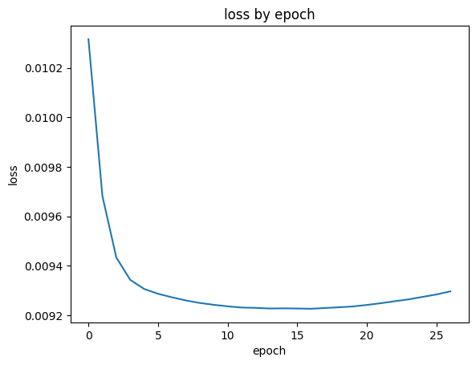

```python
# restore model and return best accuracy
res_model.load_state_dict(res_best_weights)
plt.xlabel('epoch')
plt.ylabel('loss')
plt.title('loss by epoch')
plt.plot(history)
plt.show()
```

In ra các độ đo

```python
y_pred = res_model(X_gpu_test)
y_pred_df = pd.DataFrame(y_pred.detach().numpy())
y_test_df = pd.DataFrame(y_gpu_test.detach().numpy())

mse = mean_squared_error(y_test_df, y_pred_df)
r2 = r2_score(y_test_df, y_pred_df)

print(f'MSE: {mse}')
print(f'RMSE: {np.sqrt(mse)}')
print(f'R2: {r2}')
```

```
MSE: 0.009226631373167038
RMSE: 0.09605535864830017
R2: 0.06816747256519029
```

## Kết luận

Nhóm đã tiền xử lý dữ liệu sau đó sử dụng các mô hình khác nhau nhằm tìm ra mô hình tốt nhất. Sau khi trực quan hóa phân bố của biến đầu ra và nhận thấy giá trị có dạng điệu phân bố Gamma, nhóm đã kiểm định giả thiết này cũng như sử dụng mô hình GLM đơn giản để fit cho tập dữ liệu. Các hiệu chỉnh đã được thực hiện như chỉ giữ lại các biến giải thích có ý nghĩa, phát hiện outlier, hiệu chỉnh elasticnet (Ridge, Lasso), áp dụng GAM, phương pháp Bayes. Sau đó mô hình Random Forest được sủ dụng, nhóm đã tunning các tham số để tìm ra mô hình tốt nhất. Mô hình Deep Learning được đưa vào để thử nghiệm nhưng không cho kết quả như kì vọng.

Bảng so sánh các độ đo ứng với từng mô hình

| Metric/model | GLM | GLM-elasticnet | GAM | GLM-Bayes | Random forest | DL |
| --- | --- | --- | --- | --- | --- | --- |
| **RMSE** | 0.0939 | 0.0942 | 0.0939 | 0.0936 | **0.0933** | 0.0961 |
| **R2** | 0.1102 | 0.1039 | 0.1104 | 0.1144 | **0.1217** | 0.0682 |

Nhận thấy rằng mô hình `Random Forest` thể hiện tốt nhất với $RMSE = 0.0933$ và $R2=0.1217$. Các mô hình cho ra kết quả khả tương đồng.